# Homework 4

Jake Mc Leroth

2025-04-18

```r
library(foreign)
library(mldr)
library(utiml)
library(corrplot)
library(randomForest)
library(e1071)
library(xgboost)
library(ggplot2)
library(reshape2)
```

#### In this assignment, the Scene data set is analysed. This is a multilabel data set from image data, with each image having binary labels for Beach, Sunset, Fall Folliage, Field, Mountain and Urban. The data set was first introduced by Boutell et al. (2004). The features for the data were obtained as follows:The RGB colours are converted to the Luv space. Each image was divided into a 7x7 grid of 49 squares, of which each has 3 bands corresponding to a low resolution image and texture features. The mean and variance is calculated for each bang, resulting in 49 * 3 * 2 = 294 features. The goal is to use these features to classify wether each image has a Beach, a Sunset, Fall Folliage, a Field, a Mountain or Urban.

```r
# Import data
data <- foreign::read.arff("/Users/jakemcleroth/Desktop/University/Masters/Modules/Semester 1/SLT/homework/hw_4/scene_dat")
label_indices <- 295:300
data[label_indices] <- lapply(data[label_indices], function(x) as.numeric(as.character(x)))

# Create an mldr object
data_mldr <-  mldr_from_dataframe(data, labelIndices = label_indices, name = "scene")
```

## Exploratory Data Analysis

#### An exploratory data analysis is done on the data set:

```r
# Missing values
sum(colSums(is.na(data)))
```

```
## [1] 0
```

```r
# Number of columns
data_mldr$measures$num.attributes
```

```
## [1] 300
```

```r
# Number of observations
data_mldr$measures$num.instances
```

```
## [1] 2407
```

```r
# Number of features
data_mldr$measures$num.inputs
```

```
## [1] 294
```

```r
# Number of labels
data_mldr$measures$num.labels
```

```
## [1] 6
```

#### We see there are no missing values to deal with, and confirm there are 6 labels and 294 features. There are 2407 observation (images) in the data set. The labels are looked at in more depth, first looking at the individual labels:

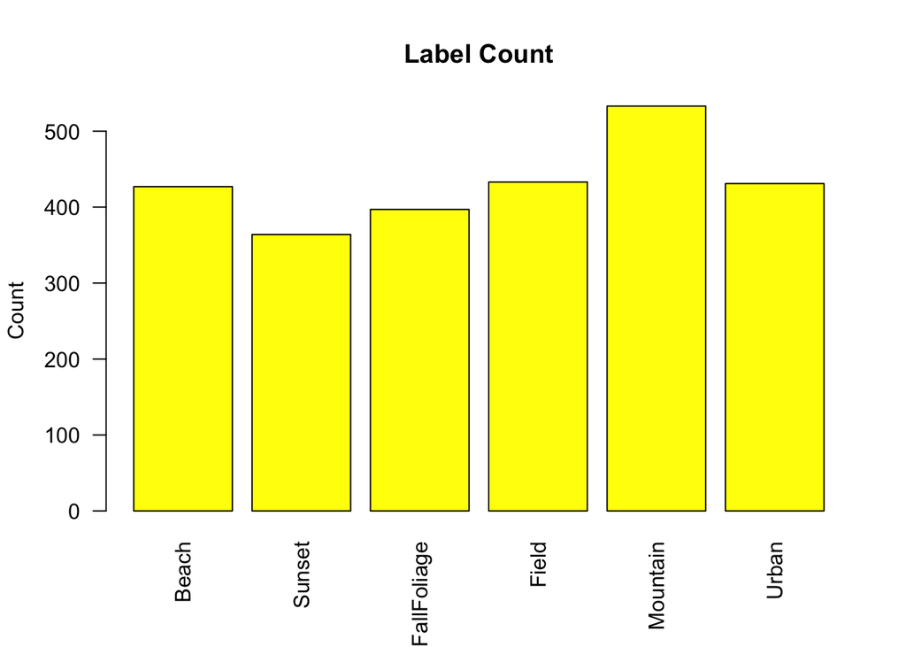

```r
# Bar plot for label counts
label_count <- data_mldr$labels$count
barplot(label_count,
        main = "Label Count",
        ylab = "Count",
        las = 2, col = "yellow", names.arg = c("Beach", "Sunset", "FallFoliage", "Field", "Mountain", "Urban"))
```

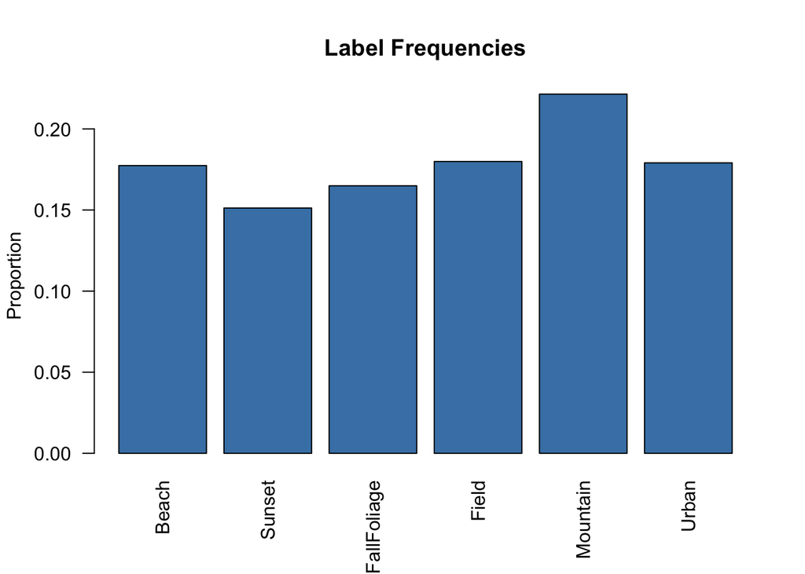

```r
# Bar plot for label frequency
label_freq <- data_mldr$labels$freq
barplot(label_freq,
        main = "Label Frequencies",
        ylab = "Proportion",
        las = 2, col = "steelblue", names.arg = c("Beach", "Sunset", "FallFoliage", "Field", "Mountain", "Urban"))
```

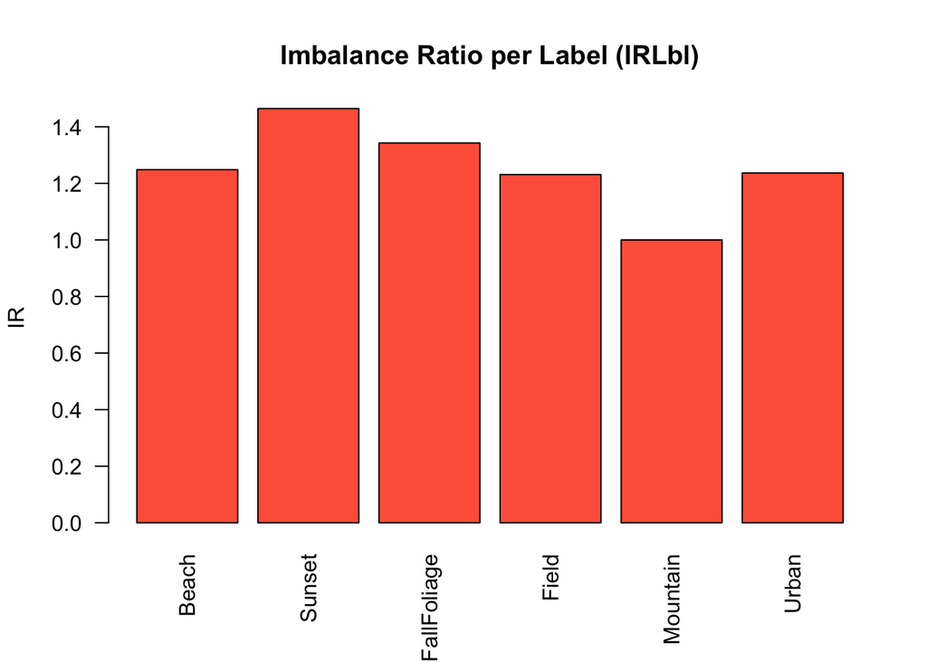

```r
# Bar plot for Imbalance Ratio
barplot(data_mldr$labels$IRLbl,
        main = "Imbalance Ratio per Label (IRLbl)",
        ylab = "IR",
        las = 2,
        col = "tomato",
        names.arg = c("Beach", "Sunset", "FallFoliage", "Field", "Mountain", "Urban"))
```

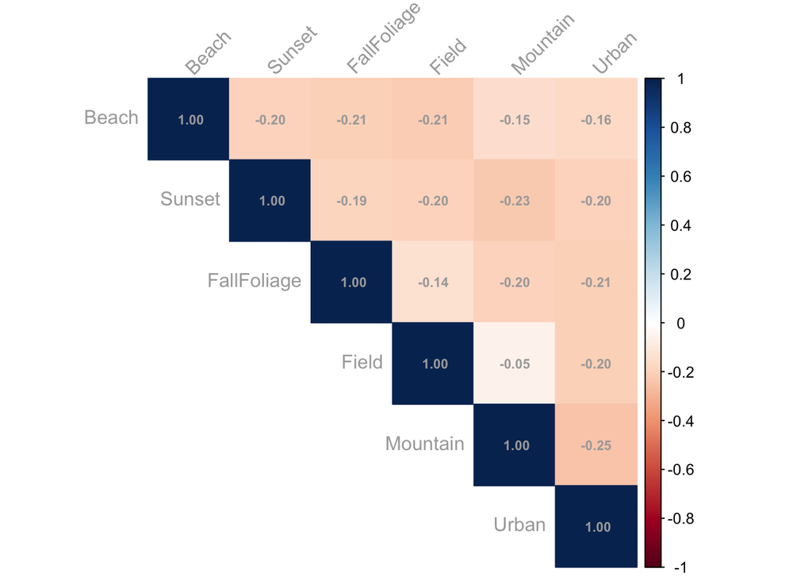

```r
# Correlation heat map
label_corr <- cor(data[, label_indices])
corrplot(label_corr,
         method = "color", type = "upper",
         tl.col = "darkgrey", tl.srt = 45,
         addCoef.col = "darkgrey", number.cex = 0.7)
```